# Como maximizar os lucros no Airbnb?

### Objetivo do projeto:

Airbnb é uma comunidade online, onde as pessoas possam anunciar e reservarem acomodações e meios de hospedagem.

A base de dados airbnb.csv (dados abertos da plataforma airbnb) contém dados de casas e apartamentos que estão disponíveis para aluguel e as características que influenciam na composição do preço da locação.

Abaixo, segue o modelo criado, realizando, preparação, análise exploratória e modelagem dos dados, para que possamos chegar no objetivo de entender as cacterísticas dos imóveis e precificar(definir valor) do aluguel de imóveis.

```python
# Importando as bibliotecas

import os
path = os.getcwd()

import numpy as np # Utilizado para operações matemáticas
import pandas as pd # Utilizado para visualização, análise e manipulação dos dados
import matplotlib as mpl # Utilizado para criação de gráficos
import matplotlib.pyplot as plt # Utilizado para criação de gráficos
import seaborn as sns # Utilizado para criação de gráficos
import statsmodels.api as sm # Mostrar resultado do modelo de previsão

%matplotlib inline

# Carregando o algoritmo para utilizar o modelo de regressão e realização de métricas

from sklearn import linear_model
from sklearn import preprocessing
from sklearn.preprocessing import StandardScaler
from sklearn.linear_model import LinearRegression
from sklearn.model_selection import train_test_split
from sklearn.metrics import explained_variance_score
from sklearn.metrics import mean_squared_error
from sklearn import metrics
from sklearn.metrics import mean_absolute_error

# Utilizado para não mostrar avisos na execução do código

import warnings
warnings.filterwarnings("ignore")
```

Para carregar o conjunto de dados do dataset, foi utilizado o meu diretório de trabalho.

```python
# Carregando o dataset do Airbnb

airbnb = pd.read_csv("airbnb.csv", sep = ',', encoding = "utf8")
```

```python
# Visualizando as primeiras linhas do dataset

airbnb.head()
```

|  | host_is_superhost | cancellation_policy | instant_bookable | host_total_listings_count | neighbourhood_cleansed | latitude | longitude | property_type | room_type | accommodates | ... | bedrooms_na | bathrooms_na | beds_na | review_scores_rating_na | review_scores_accuracy_na | review_scores_cleanliness_na | review_scores_checkin_na | review_scores_communication_na | review_scores_location_na | review_scores_value_na |
| --- | --- | --- | --- | --- | --- | --- | --- | --- | --- | --- | --- | --- | --- | --- | --- | --- | --- | --- | --- | --- | --- |
| 0 | t | moderate | t | 1.0 | Western Addition | 37.76931 | -122.43386 | Apartment | Entire home/apt | 3.0 | ... | 0.0 | 0.0 | 0.0 | 0.0 | 0.0 | 0.0 | 0.0 | 0.0 | 0.0 | 0.0 |
| 1 | f | strict_14_with_grace_period | f | 2.0 | Bernal Heights | 37.74511 | -122.42102 | Apartment | Entire home/apt | 5.0 | ... | 0.0 | 0.0 | 0.0 | 0.0 | 0.0 | 0.0 | 0.0 | 0.0 | 0.0 | 0.0 |
| 2 | f | strict_14_with_grace_period | f | 10.0 | Haight Ashbury | 37.76669 | -122.45250 | Apartment | Private room | 2.0 | ... | 0.0 | 0.0 | 0.0 | 0.0 | 0.0 | 0.0 | 0.0 | 0.0 | 0.0 | 0.0 |
| 3 | f | strict_14_with_grace_period | f | 10.0 | Haight Ashbury | 37.76487 | -122.45183 | Apartment | Private room | 2.0 | ... | 0.0 | 0.0 | 0.0 | 0.0 | 0.0 | 0.0 | 0.0 | 0.0 | 0.0 | 0.0 |
| 4 | f | strict_14_with_grace_period | f | 2.0 | Western Addition | 37.77525 | -122.43637 | House | Entire home/apt | 5.0 | ... | 0.0 | 0.0 | 0.0 | 0.0 | 0.0 | 0.0 | 0.0 | 0.0 | 0.0 | 0.0 |

5 rows × 34 columns

```python
# Visualizando o tamanho do dataset

print('\nLinhas e Colunas: ', airbnb.shape)
```

```
Linhas e Colunas:  (7146, 34)
```

```python
# Verificando o tipo dos dados do dataset

airbnb.dtypes
```

```
host_is_superhost                  object
cancellation_policy                object
instant_bookable                   object
host_total_listings_count         float64
neighbourhood_cleansed             object
latitude                          float64
longitude                         float64
property_type                      object
room_type                          object
accommodates                      float64
bathrooms                         float64
bedrooms                          float64
beds                              float64
bed_type                           object
minimum_nights                    float64
number_of_reviews                 float64
review_scores_rating              float64
review_scores_accuracy            float64
review_scores_cleanliness         float64
review_scores_checkin             float64
review_scores_communication       float64
review_scores_location            float64
review_scores_value               float64
price                             float64
bedrooms_na                       float64
bathrooms_na                      float64
beds_na                           float64
review_scores_rating_na           float64
review_scores_accuracy_na         float64
review_scores_cleanliness_na      float64
review_scores_checkin_na          float64
review_scores_communication_na    float64
review_scores_location_na         float64
review_scores_value_na            float64
dtype: object
```

Logo abaixo, conseguimos realizar um resumo/sumário estatístico de algumas colunas do dataset.

Podemos perceber que termos propriedades sem banheiros(bathrooms), sem quartos(bedrooms) e sem cama(beds).

Termos acomodações que vão de 1 dia, até 365 dias.

Média de acomodações são de 3 pessoas.

Termos propriedades sem comentários, com score de 20 até 100.

```python
# Sumário estatístico do dataset

airbnb.describe()
```

|  | host_total_listings_count | latitude | longitude | accommodates | bathrooms | bedrooms | beds | minimum_nights | number_of_reviews | review_scores_rating | ... | bedrooms_na | bathrooms_na | beds_na | review_scores_rating_na | review_scores_accuracy_na | review_scores_cleanliness_na | review_scores_checkin_na | review_scores_communication_na | review_scores_location_na | review_scores_value_na |
| --- | --- | --- | --- | --- | --- | --- | --- | --- | --- | --- | --- | --- | --- | --- | --- | --- | --- | --- | --- | --- | --- |
| count | 7146.000000 | 7146.000000 | 7146.000000 | 7146.000000 | 7146.000000 | 7146.000000 | 7146.000000 | 7146.000000 | 7146.000000 | 7146.000000 | ... | 7146.000000 | 7146.000000 | 7146.000000 | 7146.000000 | 7146.000000 | 7146.000000 | 7146.000000 | 7146.000000 | 7146.000000 | 7146.000000 |
| mean | 52.604954 | 37.765812 | -122.430534 | 3.201092 | 1.328086 | 1.342709 | 1.764484 | 15.817800 | 43.553876 | 96.034285 | ... | 0.000280 | 0.002939 | 0.000980 | 0.198853 | 0.199412 | 0.199272 | 0.199692 | 0.199132 | 0.199692 | 0.199832 |
| std | 177.428653 | 0.022531 | 0.026799 | 1.914916 | 0.793787 | 0.932855 | 1.176789 | 22.511624 | 72.538481 | 6.286139 | ... | 0.016728 | 0.054134 | 0.031285 | 0.399165 | 0.399586 | 0.399481 | 0.399797 | 0.399376 | 0.399797 | 0.399902 |
| min | 0.000000 | 37.707430 | -122.513060 | 1.000000 | 0.000000 | 0.000000 | 0.000000 | 1.000000 | 0.000000 | 20.000000 | ... | 0.000000 | 0.000000 | 0.000000 | 0.000000 | 0.000000 | 0.000000 | 0.000000 | 0.000000 | 0.000000 | 0.000000 |
| 25% | 1.000000 | 37.751140 | -122.442972 | 2.000000 | 1.000000 | 1.000000 | 1.000000 | 2.000000 | 1.000000 | 95.000000 | ... | 0.000000 | 0.000000 | 0.000000 | 0.000000 | 0.000000 | 0.000000 | 0.000000 | 0.000000 | 0.000000 | 0.000000 |
| 50% | 2.000000 | 37.767570 | -122.425490 | 2.000000 | 1.000000 | 1.000000 | 1.000000 | 4.000000 | 11.000000 | 98.000000 | ... | 0.000000 | 0.000000 | 0.000000 | 0.000000 | 0.000000 | 0.000000 | 0.000000 | 0.000000 | 0.000000 | 0.000000 |
| 75% | 8.000000 | 37.784618 | -122.411070 | 4.000000 | 1.500000 | 2.000000 | 2.000000 | 30.000000 | 54.000000 | 99.000000 | ... | 0.000000 | 0.000000 | 0.000000 | 0.000000 | 0.000000 | 0.000000 | 0.000000 | 0.000000 | 0.000000 | 0.000000 |
| max | 1199.000000 | 37.810310 | -122.369790 | 16.000000 | 14.000000 | 14.000000 | 14.000000 | 365.000000 | 677.000000 | 100.000000 | ... | 1.000000 | 1.000000 | 1.000000 | 1.000000 | 1.000000 | 1.000000 | 1.000000 | 1.000000 | 1.000000 | 1.000000 |

8 rows × 27 columns

Aqui, conseguimos ver resumo/sumário estatístico de algumas variáveis de forma individual.

Podemos ver a coluna Preço(Price), que termos valores de 10 a 10.000, com média de 213.

```python
# Sumário estatístico de algumas variáveis de forma individual

print('\nBanheiros:\n\n', airbnb.bathrooms.describe())
print('\n')
print('\nQuartos de dormir:\n\n', airbnb.bedrooms.describe())
print('\n')
print('\nPreço:\n\n', airbnb.price.describe())
```

```
Banheiros:

 count    7146.000000
mean        1.328086
std         0.793787
min         0.000000
25%         1.000000
50%         1.000000
75%         1.500000
max        14.000000
Name: bathrooms, dtype: float64



Quartos de dormir:

 count    7146.000000
mean        1.342709
std         0.932855
min         0.000000
25%         1.000000
50%         1.000000
75%         2.000000
max        14.000000
Name: bedrooms, dtype: float64



Preço:

 count     7146.000000
mean       213.309824
std        311.375499
min         10.000000
25%        100.000000
50%        150.000000
75%        235.000000
max      10000.000000
Name: price, dtype: float64
```

Agora vamos algumas analises exploradas realizando comparação das colunas do dataset.

```python
# Quantidade por tipo de propriedade

qtd_tipo_propriedade = pd.DataFrame(airbnb['property_type'].value_counts())
qtd_tipo_propriedade.columns = ['Quantidade_tipo_propriedade']
qtd_tipo_propriedade
```

|  | Quantidade_tipo_propriedade |
| --- | --- |
| Apartment | 3010 |
| House | 1990 |
| Condominium | 760 |
| Guest suite | 496 |
| Boutique hotel | 183 |
| Townhouse | 140 |
| Serviced apartment | 116 |
| Hotel | 100 |
| Loft | 93 |
| Hostel | 87 |
| Guesthouse | 44 |
| Bed and breakfast | 29 |
| Other | 22 |
| Aparthotel | 20 |
| Bungalow | 17 |
| Villa | 10 |
| Cottage | 8 |
| Resort | 8 |
| Tiny house | 3 |
| Cabin | 3 |
| Boat | 2 |
| Earth house | 1 |
| In-law | 1 |
| Timeshare | 1 |
| Castle | 1 |
| Treehouse | 1 |

```python
# Quantidade total de quartos por número de quartos

qtd_quartos= pd.DataFrame(airbnb['bedrooms'].value_counts())
qtd_quartos.columns = ['Quantidade_de_quartos']
qtd_quartos
```

|  | Quantidade_de_quartos |
| --- | --- |
| 1.0 | 4199 |
| 2.0 | 1304 |
| 0.0 | 804 |
| 3.0 | 627 |
| 4.0 | 175 |
| 5.0 | 25 |
| 6.0 | 9 |
| 7.0 | 2 |
| 14.0 | 1 |

```python
# Valor total do preço por quantidade de quarto

qtd_quartos = airbnb.filter(items = ['bedrooms', 'price']).groupby('bedrooms').sum().sort_values(['price'], ascending=[False])
qtd_quartos
```

| bedrooms | price |
| --- | --- |
| 1.0 | 625402.0 |
| 2.0 | 369160.0 |
| 3.0 | 270527.0 |
| 0.0 | 120083.0 |
| 4.0 | 98455.0 |
| 5.0 | 21244.0 |
| 6.0 | 16477.0 |
| 7.0 | 2895.0 |
| 14.0 | 69.0 |

```python
# Quantidade total de tipo de cama

qtd_cama= pd.DataFrame(airbnb['bed_type'].value_counts())
qtd_cama.columns = ['Quantidade_de_cama']
qtd_cama
```

|  | Quantidade_de_cama |
| --- | --- |
| Real Bed | 7073 |
| Futon | 32 |
| Pull-out Sofa | 23 |
| Airbed | 11 |
| Couch | 7 |

```python
# Valor total do preço por tipo de cama

total_cama = airbnb.filter(items = ['bed_type', 'price']).groupby('bed_type').sum().sort_values(['price'], ascending=[False])
total_cama
```

| bed_type | price |
| --- | --- |
| Real Bed | 1513777.0 |
| Futon | 4259.0 |
| Pull-out Sofa | 3273.0 |
| Couch | 1954.0 |
| Airbed | 1049.0 |

Vamos realizar o tratamento dos dados, verificando se tem linhas faltantes e valores NA(Nulos), no dataset.

Verificamos que todas as colunas contém todas as linhas e não termos valores Nulos.

```python
# Verificando se tem linhas vazias nas colunas

airbnb.info()
```

```
<class 'pandas.core.frame.DataFrame'>
RangeIndex: 7146 entries, 0 to 7145
Data columns (total 34 columns):
host_is_superhost                 7146 non-null object
cancellation_policy               7146 non-null object
instant_bookable                  7146 non-null object
host_total_listings_count         7146 non-null float64
neighbourhood_cleansed            7146 non-null object
latitude                          7146 non-null float64
longitude                         7146 non-null float64
property_type                     7146 non-null object
room_type                         7146 non-null object
accommodates                      7146 non-null float64
bathrooms                         7146 non-null float64
bedrooms                          7146 non-null float64
beds                              7146 non-null float64
bed_type                          7146 non-null object
minimum_nights                    7146 non-null float64
number_of_reviews                 7146 non-null float64
review_scores_rating              7146 non-null float64
review_scores_accuracy            7146 non-null float64
review_scores_cleanliness         7146 non-null float64
review_scores_checkin             7146 non-null float64
review_scores_communication       7146 non-null float64
review_scores_location            7146 non-null float64
review_scores_value               7146 non-null float64
price                             7146 non-null float64
bedrooms_na                       7146 non-null float64
bathrooms_na                      7146 non-null float64
beds_na                           7146 non-null float64
review_scores_rating_na           7146 non-null float64
review_scores_accuracy_na         7146 non-null float64
review_scores_cleanliness_na      7146 non-null float64
review_scores_checkin_na          7146 non-null float64
review_scores_communication_na    7146 non-null float64
review_scores_location_na         7146 non-null float64
review_scores_value_na            7146 non-null float64
dtypes: float64(27), object(7)
memory usage: 1.9+ MB
```

```python
# Confirmando se tem valores NA(nulos)

airbnb.isna().sum()
```

```
host_is_superhost                 0
cancellation_policy               0
instant_bookable                  0
host_total_listings_count         0
neighbourhood_cleansed            0
latitude                          0
longitude                         0
property_type                     0
room_type                         0
accommodates                      0
bathrooms                         0
bedrooms                          0
beds                              0
bed_type                          0
minimum_nights                    0
number_of_reviews                 0
review_scores_rating              0
review_scores_accuracy            0
review_scores_cleanliness         0
review_scores_checkin             0
review_scores_communication       0
review_scores_location            0
review_scores_value               0
price                             0
bedrooms_na                       0
bathrooms_na                      0
beds_na                           0
review_scores_rating_na           0
review_scores_accuracy_na         0
review_scores_cleanliness_na      0
review_scores_checkin_na          0
review_scores_communication_na    0
review_scores_location_na         0
review_scores_value_na            0
dtype: int64
```

Agora vamos criar um novo dataset contendo apenas as colunas númericas.

```python
# Salvando as colunas númericas em um uma nova variável e verificando o seu novo tamanho

airbnb_col_numericas = airbnb.select_dtypes(include='number')
airbnb_col_numericas.shape
```

```
(7146, 27)
```

```python
# Visualizando a variável que contém apenas as colunas númericas

airbnb_col_numericas.head()
```

|  | host_total_listings_count | latitude | longitude | accommodates | bathrooms | bedrooms | beds | minimum_nights | number_of_reviews | review_scores_rating | ... | bedrooms_na | bathrooms_na | beds_na | review_scores_rating_na | review_scores_accuracy_na | review_scores_cleanliness_na | review_scores_checkin_na | review_scores_communication_na | review_scores_location_na | review_scores_value_na |
| --- | --- | --- | --- | --- | --- | --- | --- | --- | --- | --- | --- | --- | --- | --- | --- | --- | --- | --- | --- | --- | --- |
| 0 | 1.0 | 37.76931 | -122.43386 | 3.0 | 1.0 | 1.0 | 2.0 | 1.0 | 180.0 | 97.0 | ... | 0.0 | 0.0 | 0.0 | 0.0 | 0.0 | 0.0 | 0.0 | 0.0 | 0.0 | 0.0 |
| 1 | 2.0 | 37.74511 | -122.42102 | 5.0 | 1.0 | 2.0 | 3.0 | 30.0 | 111.0 | 98.0 | ... | 0.0 | 0.0 | 0.0 | 0.0 | 0.0 | 0.0 | 0.0 | 0.0 | 0.0 | 0.0 |
| 2 | 10.0 | 37.76669 | -122.45250 | 2.0 | 4.0 | 1.0 | 1.0 | 32.0 | 17.0 | 85.0 | ... | 0.0 | 0.0 | 0.0 | 0.0 | 0.0 | 0.0 | 0.0 | 0.0 | 0.0 | 0.0 |
| 3 | 10.0 | 37.76487 | -122.45183 | 2.0 | 4.0 | 1.0 | 1.0 | 32.0 | 8.0 | 93.0 | ... | 0.0 | 0.0 | 0.0 | 0.0 | 0.0 | 0.0 | 0.0 | 0.0 | 0.0 | 0.0 |
| 4 | 2.0 | 37.77525 | -122.43637 | 5.0 | 1.5 | 2.0 | 2.0 | 7.0 | 27.0 | 97.0 | ... | 0.0 | 0.0 | 0.0 | 0.0 | 0.0 | 0.0 | 0.0 | 0.0 | 0.0 | 0.0 |

5 rows × 27 columns

### Chegou a hora de utilizar os gráficos para análise exploratoria.

Em um dos gráficos abaixo, podemos ver:

Quantidade maior de até dois banheiros.

Quantidade maior de até duas camas.

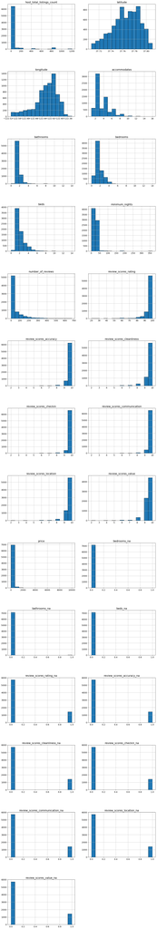

```python
# Vamos criar gráficos para todas as variáveis númericas

plt.rcParams.update({'font.size': 13})

columns = airbnb_col_numericas.columns[:]
plt.subplots(figsize=(16,200))
length = len(columns)

for i,j in zip(columns,range(length)):
    plt.subplot((length/1),2,j+1)
    plt.subplots_adjust(wspace=0.2,hspace=0.5)
    airbnb[i].hist(bins=15,edgecolor='black')
    plt.title(i)

plt.show()
```

Na fígura abaixo, podemos ver que termos aluguel que chegam a ser mais altos com a quantidade maior com dois quartos.

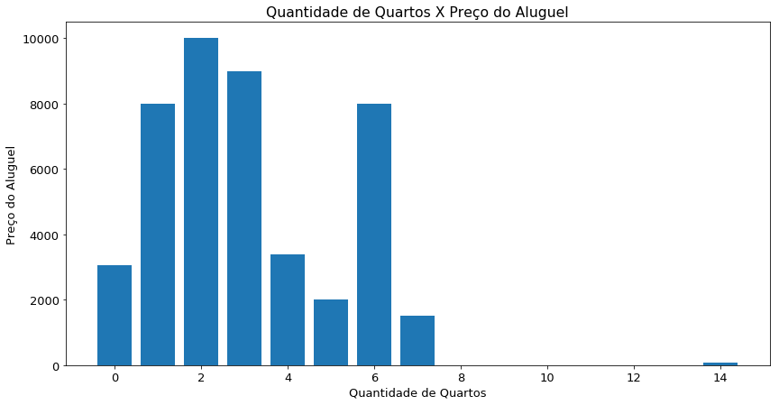

```python
# Comparando a relação de número de quartos com o preço do aluguel

print('\n')

plt.rcParams['figure.figsize'] = (14,7)
plt.bar(airbnb.bedrooms, airbnb.price)
plt.xlabel("Quantidade de Quartos")
plt.ylabel("Preço do Aluguel")
plt.title("Quantidade de Quartos X Preço do Aluguel")
plt.show()
```

Termos muito mais uma quantidade maior para camas do tipo Real Bed, creio que seja camas mais tradicionais, com preços chegam a ser mais altos.

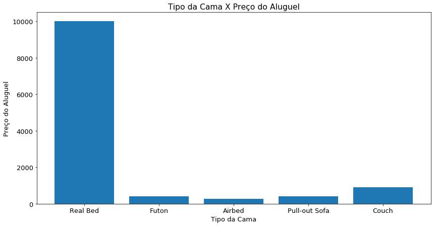

```python
# Comparando a relação do tipo da cama com o preço do aluguel

print('\n')

plt.bar(airbnb.bed_type, airbnb.price)
plt.xlabel("Tipo da Cama")
plt.ylabel("Preço do Aluguel")
plt.title("Tipo da Cama X Preço do Aluguel")
plt.show()
```

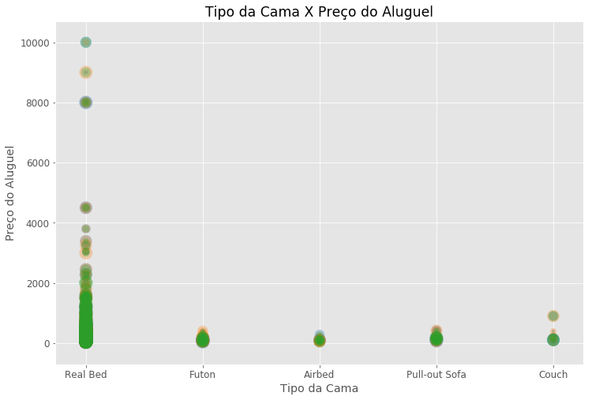

```python
# Mudando a visualização do gráfico de cima

plt.rcParams.update({'font.size': 12})
fig, ax = plt.subplots(figsize=(12,8))


for color in ['tab:blue', 'tab:orange', 'tab:green']:
    x = airbnb.bed_type
    y = airbnb.price
    plt.xlabel("Tipo da Cama")
    plt.ylabel("Preço do Aluguel")
    plt.title("Tipo da Cama X Preço do Aluguel")
    scale = 300 * np.random.rand(100)
    ax.scatter(x, y, c=color, s=scale, label=color,
               alpha=0.3, edgecolors='none')

ax.grid(True)

plt.show()
```

Quantidade de até cem comentarios são os que tem com maior frequência.

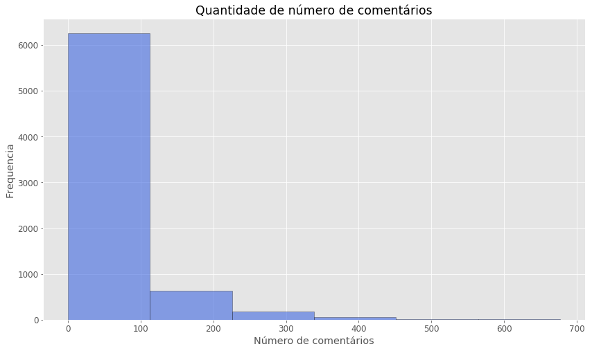

```python
# Visualizando a frequência de quantidade de comentários

plt.style.use("ggplot")
plt.figure(figsize = (14, 8))
plt.rcParams.update({'font.size': 12})
airbnb["number_of_reviews"].hist(bins = 6, ec = "k", alpha = .6, color = "royalblue")
plt.xlabel("Número de comentários")
plt.ylabel("Frequencia")
plt.title("Quantidade de número de comentários")
plt.show()
```

Aqui conseguimos ver que termos pontuação que varia de 20 até 100, sendo que a maiorias das pessoas realização mais as pesquisas onde se teve uma boa pontuação.

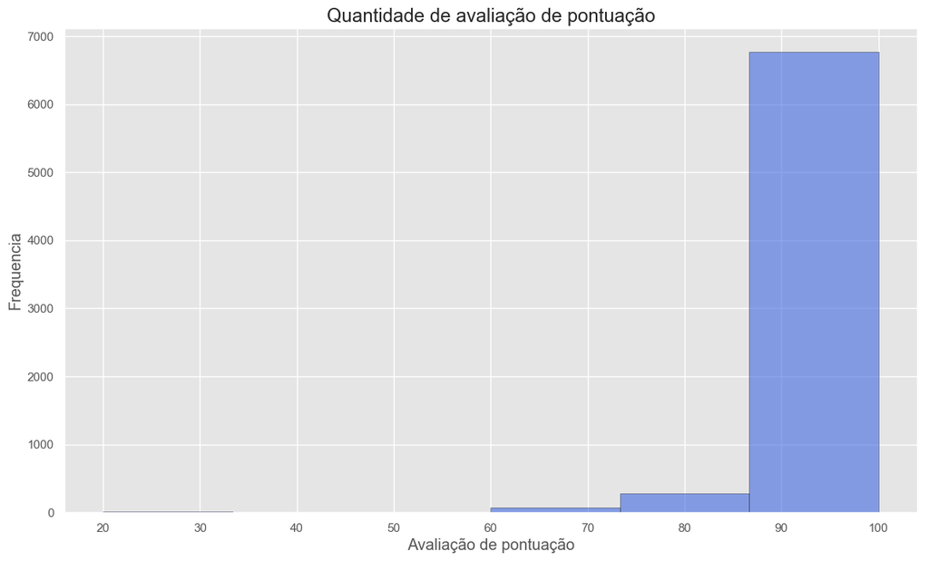

```python
# Visualizar a frequência de quantidade de avaliação de pontuação

plt.style.use("ggplot")
plt.figure(figsize = (14, 8))
plt.rcParams.update({'font.size': 12})
airbnb["review_scores_rating"].hist(bins = 6, ec = "k", alpha = .6, color = "royalblue")
plt.xlabel("Avaliação de pontuação")
plt.ylabel("Frequencia")
plt.title("Quantidade de avaliação de pontuação")
plt.show()
```

Podemos perceber que a região da propriedade, influência no preço do aluguel.

```
[Text(0,0.5,'Preço'),
 Text(0.5,0,'Bairro (Região)'),
 Text(0.5,1,'Bairro (Região) X Preço')]
```

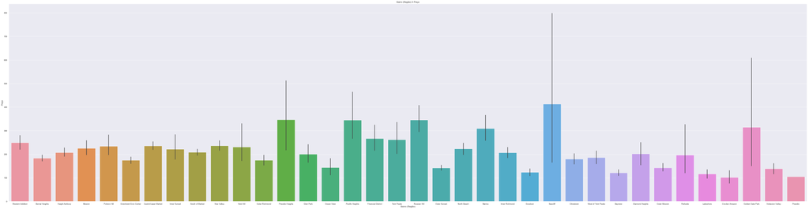

```python
# Comparando os bairros (Regiões) com o preço.
# Obersavação: Abra o gráfico em uma nova Guia, clicando com botão direito -> Abrir imagem em uma nova guia

sns.set(rc={'figure.figsize':(80,20)})
sns.barplot(x= 'neighbourhood_cleansed', y = 'price', data=airbnb) \
.set(title='Bairro (Região) X Preço', xlabel='Bairro (Região)', ylabel='Preço')
```

Aqui também conseguimos ver que pontuação menores que seis, possuem uma menor pontuação da classificação do aluguel.

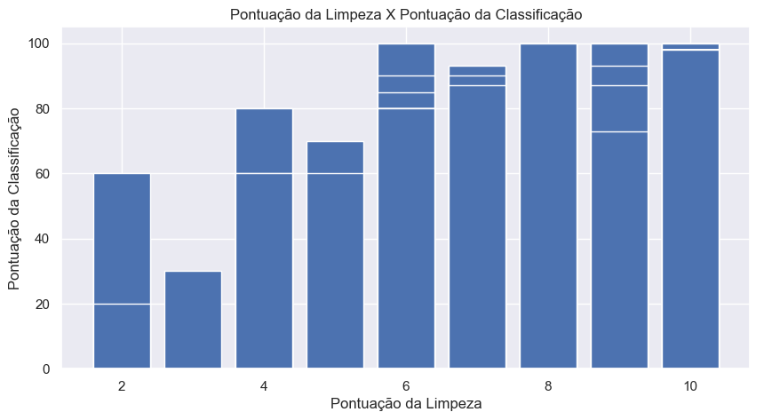

```python
# Comparando a relação da pontuação da limpeza com o pontuação da classificação

plt.rcParams['figure.figsize'] = (10,5)
plt.rcParams.update({'font.size': 12})
plt.bar(airbnb.review_scores_cleanliness, airbnb.review_scores_rating)
plt.xlabel("Pontuação da Limpeza")
plt.ylabel("Pontuação da Classificação")
plt.title("Pontuação da Limpeza X Pontuação da Classificação")
plt.show()
```

Propriedades que oferecem cancelamento flexível, tem quantidade maior com preços que chegam a ser mais altos.

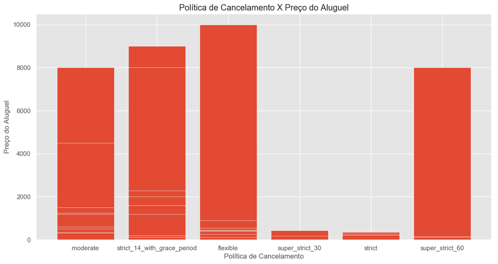

```python
# Comparando a relação política de cancelamento com o preço do aluguel

plt.rcParams['figure.figsize'] = (14,7)
plt.rcParams.update({'font.size': 10})
plt.bar(airbnb.cancellation_policy, airbnb.price)
plt.xlabel("Política de Cancelamento")
plt.ylabel("Preço do Aluguel")
plt.title("Política de Cancelamento X Preço do Aluguel")
plt.show()
```

A quantidade é muito maior com preços que chegam a ser mais altos, com propriedades do tipo, condomio, casa e apartamento.

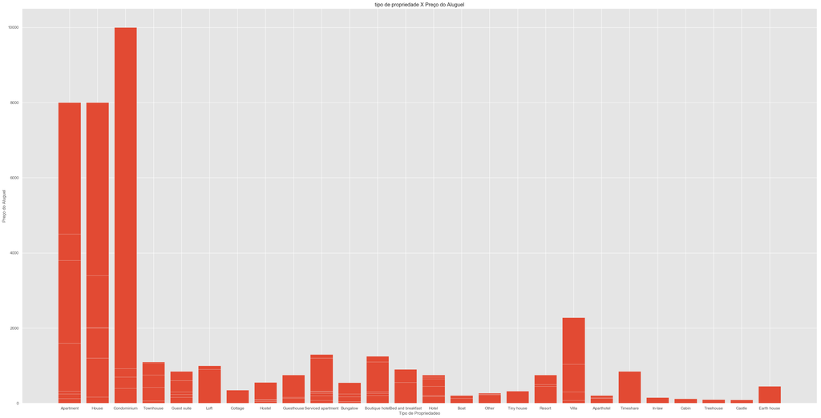

```python
# Comparando a relação tipo de propriedade com o preço do aluguel
# Obersavação: Abra o gráfico em uma nova Guia, clicando com botão direito -> Abrir imagem em uma nova guia

plt.rcParams['figure.figsize'] = (40,20)
plt.rcParams.update({'font.size': 10})
plt.bar(airbnb.property_type, airbnb.price)
plt.xlabel("Tipo de propriedade")
plt.ylabel("Preço do Aluguel")
plt.title("tipo de propriedade X Preço do Aluguel")
plt.show()
```

### Agora vamos realizar a correlação entre as variáveis.

Podemos ver que a correlação é muito baixa da variável Price com as demais variáveis númericas do dataset.

```python
# Distribuição das classe

airbnb_col_numericas.corr(method = 'pearson')
```

|  | host_total_listings_count | latitude | longitude | accommodates | bathrooms | bedrooms | beds | minimum_nights | number_of_reviews | review_scores_rating | ... | bedrooms_na | bathrooms_na | beds_na | review_scores_rating_na | review_scores_accuracy_na | review_scores_cleanliness_na | review_scores_checkin_na | review_scores_communication_na | review_scores_location_na | review_scores_value_na |
| --- | --- | --- | --- | --- | --- | --- | --- | --- | --- | --- | --- | --- | --- | --- | --- | --- | --- | --- | --- | --- | --- |
| host_total_listings_count | 1.000000 | 0.168420 | 0.179394 | -0.031795 | -0.009684 | -0.044223 | -0.070620 | 0.168062 | -0.162465 | 0.026785 | ... | -0.002981 | -0.012950 | -0.005956 | 0.308821 | 0.308090 | 0.308273 | 0.307728 | 0.308456 | 0.307728 | 0.307547 |
| latitude | 0.168420 | 1.000000 | 0.186439 | -0.040640 | 0.043451 | -0.101949 | -0.048615 | 0.146478 | -0.116828 | -0.013030 | ... | 0.015008 | 0.045186 | 0.014314 | 0.168140 | 0.167269 | 0.167420 | 0.167448 | 0.167605 | 0.167448 | 0.167780 |
| longitude | 0.179394 | 0.186439 | 1.000000 | -0.079097 | -0.009345 | -0.105547 | -0.088636 | 0.111562 | -0.123448 | 0.012461 | ... | -0.014056 | 0.025316 | 0.018139 | 0.122144 | 0.121281 | 0.121356 | 0.120575 | 0.122189 | 0.120575 | 0.120375 |
| accommodates | -0.031795 | -0.040640 | -0.079097 | 1.000000 | 0.351962 | 0.758461 | 0.832837 | -0.044867 | -0.081727 | 0.064387 | ... | 0.024458 | -0.038105 | -0.021978 | -0.038223 | -0.037964 | -0.038120 | -0.038383 | -0.037910 | -0.038383 | -0.038593 |
| bathrooms | -0.009684 | 0.043451 | -0.009345 | 0.351962 | 1.000000 | 0.412040 | 0.378792 | 0.012361 | -0.074755 | -0.016756 | ... | 0.019434 | -0.022440 | 0.012418 | 0.008742 | 0.009477 | 0.008742 | 0.009844 | 0.008889 | 0.009844 | 0.009697 |
| bedrooms | -0.044223 | -0.101949 | -0.105547 | 0.758461 | 0.412040 | 1.000000 | 0.738282 | -0.019659 | -0.096674 | 0.090982 | ... | -0.006147 | -0.019946 | -0.011505 | -0.045476 | -0.045192 | -0.045450 | -0.045425 | -0.045334 | -0.045425 | -0.045542 |
| beds | -0.070620 | -0.048615 | -0.088636 | 0.832837 | 0.378792 | 0.738282 | 1.000000 | -0.009402 | -0.083029 | 0.033236 | ... | 0.010458 | -0.011104 | -0.020344 | -0.042110 | -0.042083 | -0.042164 | -0.042515 | -0.041947 | -0.042515 | -0.042732 |
| minimum_nights | 0.168062 | 0.146478 | 0.111562 | -0.044867 | 0.012361 | -0.019659 | -0.009402 | 1.000000 | -0.231655 | -0.083277 | ... | 0.010542 | -0.005303 | 0.014164 | 0.269920 | 0.271000 | 0.270851 | 0.270848 | 0.270234 | 0.270848 | 0.270997 |
| number_of_reviews | -0.162465 | -0.116828 | -0.123448 | -0.081727 | -0.074755 | -0.096674 | -0.083029 | -0.231655 | 1.000000 | -0.011460 | ... | -0.009124 | 0.084805 | -0.017508 | -0.298929 | -0.299426 | -0.299299 | -0.299679 | -0.299173 | -0.299679 | -0.299805 |
| review_scores_rating | 0.026785 | -0.013030 | 0.012461 | 0.064387 | -0.016756 | 0.090982 | 0.033236 | -0.083277 | -0.011460 | 1.000000 | ... | 0.001240 | -0.029909 | 0.011216 | 0.155803 | 0.152065 | 0.151884 | 0.152427 | 0.156163 | 0.152427 | 0.151494 |
| review_scores_accuracy | 0.021991 | -0.021110 | -0.006865 | 0.028920 | -0.039171 | 0.036646 | 0.001303 | -0.094549 | 0.056721 | 0.699940 | ... | -0.008904 | -0.018153 | -0.012947 | 0.148714 | 0.148975 | 0.148910 | 0.149106 | 0.148845 | 0.149106 | 0.148009 |
| review_scores_cleanliness | 0.050223 | -0.005867 | 0.010879 | 0.022402 | -0.086821 | 0.026387 | -0.030356 | -0.081536 | 0.019613 | 0.669338 | ... | 0.007142 | -0.053960 | -0.031123 | 0.212673 | 0.211056 | 0.212953 | 0.211244 | 0.212860 | 0.211244 | 0.211338 |
| review_scores_checkin | 0.002453 | -0.041226 | -0.031385 | 0.018343 | -0.034149 | 0.024735 | -0.001650 | -0.099201 | 0.075758 | 0.489325 | ... | 0.003883 | -0.004688 | -0.022644 | 0.115609 | 0.115812 | 0.115761 | 0.115913 | 0.115710 | 0.115913 | 0.115964 |
| review_scores_communication | -0.014081 | -0.039130 | -0.026124 | 0.027383 | -0.024551 | 0.025988 | 0.008401 | -0.101414 | 0.061241 | 0.605232 | ... | -0.011937 | -0.006573 | -0.009498 | 0.121275 | 0.116126 | 0.116072 | 0.116236 | 0.121382 | 0.116236 | 0.116290 |
| review_scores_location | 0.025204 | 0.201675 | -0.010708 | 0.022239 | -0.031300 | 0.026358 | 0.002764 | -0.023083 | -0.010420 | 0.481081 | ... | -0.005562 | 0.011365 | 0.006555 | 0.212262 | 0.212635 | 0.212541 | 0.212821 | 0.212448 | 0.212821 | 0.212914 |
| review_scores_value | 0.047182 | -0.014218 | 0.012213 | -0.022997 | -0.023890 | 0.001171 | -0.031413 | -0.043438 | -0.022514 | 0.685752 | ... | -0.011674 | -0.017238 | 0.001962 | 0.315311 | 0.315865 | 0.315726 | 0.316142 | 0.315588 | 0.316142 | 0.316280 |
| price | -0.012935 | 0.104869 | 0.021325 | 0.372839 | 0.183564 | 0.360764 | 0.317993 | -0.032403 | -0.096274 | 0.084402 | ... | 0.009334 | -0.023062 | -0.010792 | 0.020898 | 0.020624 | 0.020645 | 0.020313 | 0.020778 | 0.020313 | 0.020203 |
| bedrooms_na | -0.002981 | 0.015008 | -0.014056 | 0.024458 | 0.019434 | -0.006147 | 0.010458 | 0.010542 | -0.009124 | 0.001240 | ... | 1.000000 | -0.000908 | -0.000524 | 0.012624 | 0.012587 | 0.012597 | 0.012569 | 0.012606 | 0.012569 | 0.012560 |
| bathrooms_na | -0.012950 | 0.045186 | 0.025316 | -0.038105 | -0.022440 | -0.019946 | -0.011104 | -0.005303 | 0.084805 | -0.029909 | ... | -0.000908 | 1.000000 | 0.080941 | -0.027047 | -0.027095 | -0.027083 | -0.027119 | -0.027071 | -0.027119 | -0.027131 |
| beds_na | -0.005956 | 0.014314 | 0.018139 | -0.021978 | 0.012418 | -0.011505 | -0.020344 | 0.014164 | -0.017508 | 0.011216 | ... | -0.000524 | 0.080941 | 1.000000 | 0.018022 | 0.017959 | 0.017975 | 0.017928 | 0.017991 | 0.017928 | 0.017912 |
| review_scores_rating_na | 0.308821 | 0.168140 | 0.122144 | -0.038223 | 0.008742 | -0.045476 | -0.042110 | 0.269920 | -0.298929 | 0.155803 | ... | 0.012624 | -0.027047 | 0.018022 | 1.000000 | 0.998247 | 0.998684 | 0.997372 | 0.999122 | 0.997372 | 0.996936 |
| review_scores_accuracy_na | 0.308090 | 0.167269 | 0.121281 | -0.037964 | 0.009477 | -0.045192 | -0.042083 | 0.271000 | -0.299426 | 0.152065 | ... | 0.012587 | -0.027095 | 0.017959 | 0.998247 | 1.000000 | 0.999562 | 0.999124 | 0.999123 | 0.999124 | 0.998687 |
| review_scores_cleanliness_na | 0.308273 | 0.167420 | 0.121356 | -0.038120 | 0.008742 | -0.045450 | -0.042164 | 0.270851 | -0.299299 | 0.151884 | ... | 0.012597 | -0.027083 | 0.017975 | 0.998684 | 0.999562 | 1.000000 | 0.998686 | 0.999561 | 0.998686 | 0.998249 |
| review_scores_checkin_na | 0.307728 | 0.167448 | 0.120575 | -0.038383 | 0.009844 | -0.045425 | -0.042515 | 0.270848 | -0.299679 | 0.152427 | ... | 0.012569 | -0.027119 | 0.017928 | 0.997372 | 0.999124 | 0.998686 | 1.000000 | 0.998248 | 1.000000 | 0.999562 |
| review_scores_communication_na | 0.308456 | 0.167605 | 0.122189 | -0.037910 | 0.008889 | -0.045334 | -0.041947 | 0.270234 | -0.299173 | 0.156163 | ... | 0.012606 | -0.027071 | 0.017991 | 0.999122 | 0.999123 | 0.999561 | 0.998248 | 1.000000 | 0.998248 | 0.997812 |
| review_scores_location_na | 0.307728 | 0.167448 | 0.120575 | -0.038383 | 0.009844 | -0.045425 | -0.042515 | 0.270848 | -0.299679 | 0.152427 | ... | 0.012569 | -0.027119 | 0.017928 | 0.997372 | 0.999124 | 0.998686 | 1.000000 | 0.998248 | 1.000000 | 0.999562 |
| review_scores_value_na | 0.307547 | 0.167780 | 0.120375 | -0.038593 | 0.009697 | -0.045542 | -0.042732 | 0.270997 | -0.299805 | 0.151494 | ... | 0.012560 | -0.027131 | 0.017912 | 0.996936 | 0.998687 | 0.998249 | 0.999562 | 0.997812 | 0.999562 | 1.000000 |

27 rows × 27 columns

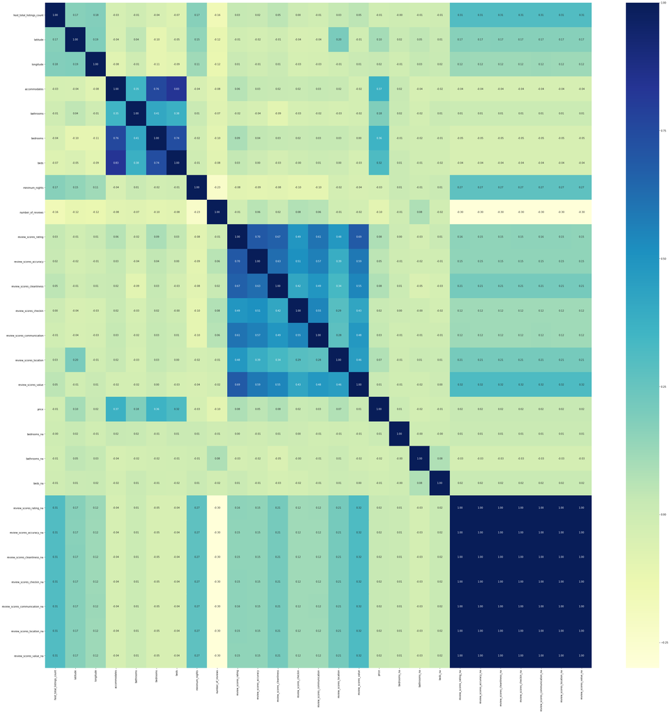

```python
# Visualizando correlação entre as varíaveis através do gráfico

plt.figure(figsize=(50,50))
cor = airbnb_col_numericas.corr()
sns.heatmap(cor, annot=True, cmap="YlGnBu", fmt=".2f")
plt.show()
```

```python
# Função para criar o gráfico de dispersão.
# Compara as varíaveis independente(Price) que mais tem correlação linear com a varíavel dependente.

def corr_linear(coluna_independente, coluna_dependente, titulo_x, titulo_y):
    plt.figure(figsize=(10,5))
    plt.rcParams.update({'font.size': 12})
    plt.scatter(coluna_independente, coluna_dependente)
    print('\n')
    plt.title(titulo_x+' X '+titulo_y)
    plt.xlabel(titulo_x)
    plt.ylabel(titulo_y)
    plt.show()
```

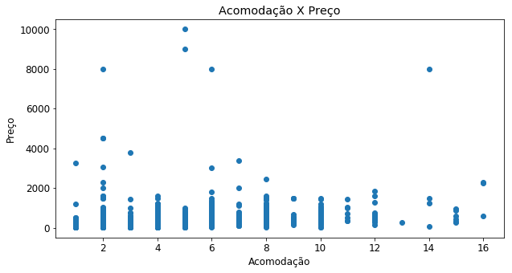

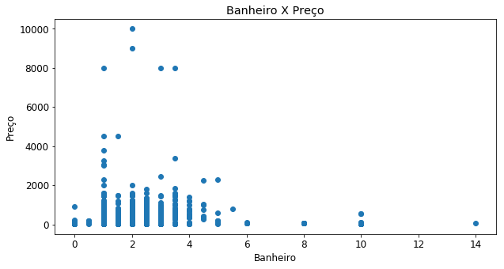

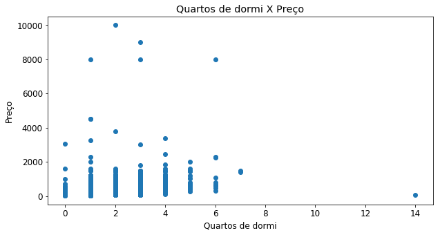

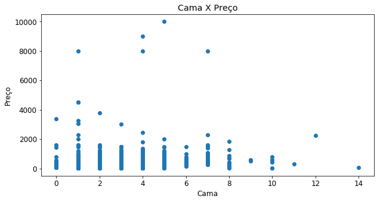

```python
# Chamando a função para exibir os gráficos

corr_linear(airbnb.accommodates, airbnb.price, "Acomodação", "Preço")

print('\n')

corr_linear(airbnb.bathrooms, airbnb.price, "Banheiro", "Preço")

print('\n')

corr_linear(airbnb.bedrooms, airbnb.price, "Quartos de dormi", "Preço")

print('\n')

corr_linear(airbnb.beds, airbnb.price, "Cama", "Preço")

print('\n')
```

# Preparando o modelo para machine learning

Definimos que a variável Price, será a variável target(preditora), que queremos realizar a previsão.

Para o modelo de machine learning, iremos utilizar o método de Regressão.

### **Modelo 01**

```python
# Passando variáveis preditoras para X. Vamos utilizar as variáveis númericas, retirando a variável Price que queremos prever.
# Passando variável target para Y.

X = airbnb_col_numericas.drop('price', axis=1)

Y = airbnb['price']

test_size = 0.30
seed = 50
```

```python
# Vamos usar a Padronização (StandardScaler).
# Está técnica ajusta os coeficientes e torna a superfície de erros mais "tratável".

scaler = StandardScaler()
X = StandardScaler().fit_transform(X)
scaler
```

```
StandardScaler(copy=True, with_mean=True, with_std=True)
```

```python
# Utilização train_test_split, para dividir os dados em 70% para treino e 30% para teste

X_train, X_test, Y_train, Y_test = train_test_split(X, Y, test_size=test_size, random_state=seed)
```

```python
# Modelo regressão linear

reg_log = linear_model.LinearRegression()
reg_log.fit(X_train,Y_train)

Y_pred = reg_log.predict(X_test)
```

```python
# Erro médio quadrado e erro médio absoluto

from sklearn.metrics import mean_squared_error

mean_squared_error = mean_squared_error(Y_test, Y_pred)

erro_medio_absoluto = mean_absolute_error(Y_test, Y_pred)
```

```python
# Exibindo os resultados

print ("\nCoeficiente de determinação  r² com dados de treino:", round(reg_log.score(X_train,Y_train), 2) * 100,'%')

print ("\nCoeficiente de determinação r² com os dados de teste:", round(reg_log.score(X_test,Y_test), 2) * 100,'%')

print("\nErro médio quadrado: ", round(mean_squared_error))

print("\nErro médio absoluto:", round(erro_medio_absoluto))
```

```
Coeficiente de determinação  r² com dados de treino: 25.0 %

Coeficiente de determinação r² com os dados de teste: 10.0 %

Erro médio quadrado:  134500.0

Erro médio absoluto: 99.0
```

```python
# Exibindo os resultados de forma detalhada

resultado = sm.add_constant(X_train)
LR_model = sm.OLS(Y_train, resultado).fit()
print(LR_model.summary())
```

```
                            OLS Regression Results
==============================================================================
Dep. Variable:                  price   R-squared:                       0.252
Model:                            OLS   Adj. R-squared:                  0.248
Method:                 Least Squares   F-statistic:                     67.08
Date:                Sun, 21 Feb 2021   Prob (F-statistic):          1.63e-290
Time:                        18:39:08   Log-Likelihood:                -34423.
No. Observations:                5002   AIC:                         6.890e+04
Df Residuals:                    4976   BIC:                         6.907e+04
Df Model:                          25
Covariance Type:            nonrobust
==============================================================================
                 coef    std err          t      P>|t|      [0.025      0.975]
------------------------------------------------------------------------------
const        209.7793      3.344     62.739      0.000     203.224     216.334
x1           -13.3985      3.626     -3.695      0.000     -20.507      -6.290
x2            41.0576      3.622     11.336      0.000      33.957      48.158
x3            11.5507      3.478      3.321      0.001       4.733      18.369
x4            75.7138      6.816     11.108      0.000      62.352      89.076
x5             7.7679      3.807      2.041      0.041       0.305      15.231
x6            70.5804      5.643     12.508      0.000      59.518      81.642
x7           -22.8280      6.448     -3.540      0.000     -35.469     -10.187
x8            -7.2659      3.565     -2.038      0.042     -14.256      -0.276
x9           -16.7015      3.646     -4.581      0.000     -23.848      -9.555
x10           23.6357      6.476      3.650      0.000      10.940      36.331
x11           -2.2742      5.200     -0.437      0.662     -12.469       7.921
x12           20.1766      4.952      4.075      0.000      10.469      29.884
x13           -2.3347      4.474     -0.522      0.602     -11.105       6.436
x14            2.7636      4.806      0.575      0.565      -6.658      12.185
x15            5.1515      3.987      1.292      0.196      -2.666      12.969
x16          -25.9065      5.077     -5.103      0.000     -35.860     -15.953
x17           -1.9155      3.961     -0.484      0.629      -9.681       5.850
x18           -2.3118      3.347     -0.691      0.490      -8.873       4.250
x19           -1.8963      2.821     -0.672      0.502      -7.427       3.635
x20           31.6637     66.817      0.474      0.636     -99.326     162.654
x21           43.8167    116.238      0.377      0.706    -184.061     271.694
x22          129.0646    140.717      0.917      0.359    -146.803     404.932
x23          -17.2403     58.058     -0.297      0.767    -131.059      96.579
x24         -163.0978    122.239     -1.334      0.182    -402.739      76.544
x25          -17.2403     58.058     -0.297      0.767    -131.059      96.579
x26           -6.6863     95.010     -0.070      0.944    -192.949     179.576
==============================================================================
Omnibus:                    10673.834   Durbin-Watson:                   1.993
Prob(Omnibus):                  0.000   Jarque-Bera (JB):         61821649.994
Skew:                          18.508   Prob(JB):                         0.00
Kurtosis:                     546.374   Cond. No.                     2.25e+15
==============================================================================

Warnings:
[1] Standard Errors assume that the covariance matrix of the errors is correctly specified.
[2] The smallest eigenvalue is 7.63e-27. This might indicate that there are
strong multicollinearity problems or that the design matrix is singular.
```

### **Modelo 02**

```python
# Deixando apenas as colunas que contém alguma correlação com a coluna Price

colunas = ['accommodates', 'bathrooms', 'bedrooms', 'beds_na', 'beds']
x2 = airbnb_col_numericas.filter(items = colunas)
```

```python
# Visualizando as primeiras linhas das colunas escolhidas

x2.head()
```

|  | accommodates | bathrooms | bedrooms | beds_na | beds |
| --- | --- | --- | --- | --- | --- |
| 0 | 3.0 | 1.0 | 1.0 | 0.0 | 2.0 |
| 1 | 5.0 | 1.0 | 2.0 | 0.0 | 3.0 |
| 2 | 2.0 | 4.0 | 1.0 | 0.0 | 1.0 |
| 3 | 2.0 | 4.0 | 1.0 | 0.0 | 1.0 |
| 4 | 5.0 | 1.5 | 2.0 | 0.0 | 2.0 |

```python
# Passando variáveis preditoras para X
# Passando variável target para Y

X2 = x2

Y2 = airbnb['price']

test_size2 = 0.30
random_state = 42
```

```python
# Vamos usar a Padronização (StandardScaler).
# Está técnica ajusta os coeficientes e torna a superfície de erros mais "tratável".

scaler2 = StandardScaler()
X2 = StandardScaler().fit_transform(X)
scaler2
```

```
StandardScaler(copy=True, with_mean=True, with_std=True)
```

```python
# Utilização train_test_split, para dividir os dados em 70% para treino e 30% para teste

X_train2, X_test2, Y_train2, Y_test2 = train_test_split(X2, Y2, test_size=test_size2, random_state=random_state)
```

```python
# Modelo regressão linear

reg_log2 = linear_model.LinearRegression()
reg_log.fit(X_train2,Y_train2)

Y_pred2 = reg_log.predict(X_test2)
```

```python
# Erro médio quadrado e erro médio absoluto

from sklearn.metrics import mean_squared_error

mean_squared_error2 = mean_squared_error(Y_test2, Y_pred2)

erro_medio_absoluto2 = mean_absolute_error(Y_test2, Y_pred2)
```

```python
# Exibindo os resultados

print ("\nCoeficiente de determinação  r² com dados de treino:", round(reg_log.score(X_train2,Y_train2), 2) * 100,'%')

print ("\nCoeficiente de determinação r² com os dados de teste:", round(reg_log.score(X_test2,Y_test2), 2) * 100,'%')

print("\nErro médio quadrado: ", round(mean_squared_error2))

print("\nErro médio absoluto:", round(erro_medio_absoluto2))
```

```
Coeficiente de determinação  r² com dados de treino: 13.0 %

Coeficiente de determinação r² com os dados de teste: 31.0 %

Erro médio quadrado:  29896.0

Erro médio absoluto: 91.0
```

```python
# Exibindo os resultados de forma detalhada

resultado2 = sm.add_constant(X_train2)
LR_model2 = sm.OLS(Y_train, resultado2).fit()
print(LR_model2.summary())
```

[output not shown]

```python
# Tabela comparando valor do preço real com a previsão

print('Tabela da comparação dos valores real e previstos:')

pd.DataFrame(list(zip(Y_test2[10:20], Y_pred2[10:20])), columns=['Preço','Previsao'])
```

```
Tabela da comparação dos valores real e previstos:
```

|  | Preço | Previsao |
| --- | --- | --- |
| 0 | 410.0 | 724.395043 |
| 1 | 235.0 | 418.682396 |
| 2 | 148.0 | 147.788437 |
| 3 | 100.0 | 147.788437 |
| 4 | 100.0 | 147.788437 |
| 5 | 69.0 | 147.788437 |
| 6 | 299.0 | 297.489272 |
| 7 | 290.0 | 283.235417 |
| 8 | 77.0 | 215.354300 |
| 9 | 133.0 | 147.788437 |

### **Modelo 03**

```python
# Deixando apenas as colunas que contém alguma correlação com a coluna Price

colunas2 = ['accommodates', 'bathrooms', 'bedrooms', 'beds_na', 'beds']
x3 = airbnb_col_numericas.filter(items = colunas2)
```

```python
# Passando variáveis preditoras para X
# Passando variável target para Y

X3 = x3

Y3 = airbnb['price']
```

```python
# Utilização train_test_split, para dividir os dados em 70% para treino e 30% para teste

X_train3, X_test3, Y_train3, Y_test3 = train_test_split(X3,
                                                    Y3,
                                                    test_size=0.30,
                                                    random_state=5)
```

```python
# Modelo regressão linear

reg_log3 = linear_model.LinearRegression()
reg_log.fit(X_train3,Y_train3)

Y_pred3 = reg_log.predict(X_test3)
```

```python
# Erro médio quadrado e erro médio absoluto

from sklearn.metrics import mean_squared_error

mean_squared_error3 = mean_squared_error(Y_test3, Y_pred3)

erro_medio_absoluto3 = mean_absolute_error(Y_test3, Y_pred3)
```

```python
# Exibindo os resultados

print ("\nCoeficiente de determinação  r² com dados de treino:", round(reg_log.score(X_train3,Y_train3), 2) * 100,'%')

print ("\nCoeficiente de determinação r² com os dados de teste:", round(reg_log.score(X_test3,Y_test3), 2) * 100,'%')

print("\nErro médio quadrado: ", round(mean_squared_error3))

print("\nErro médio absoluto:", round(erro_medio_absoluto3))
```

```
Coeficiente de determinação  r² com dados de treino: 15.0 %

Coeficiente de determinação r² com os dados de teste: 16.0 %

Erro médio quadrado:  59830.0

Erro médio absoluto: 93.0
```

```python
# Exibindo os resultados de forma detalhada

resultado3 = sm.add_constant(X_train3)
LR_model3 = sm.OLS(Y_train3, resultado3).fit()
print(LR_model3.summary())
```

```
                            OLS Regression Results
==============================================================================
Dep. Variable:                  price   R-squared:                       0.151
Model:                            OLS   Adj. R-squared:                  0.151
Method:                 Least Squares   F-statistic:                     178.2
Date:                Sun, 21 Feb 2021   Prob (F-statistic):          5.03e-175
Time:                        19:26:15   Log-Likelihood:                -35668.
No. Observations:                5002   AIC:                         7.135e+04
Df Residuals:                    4996   BIC:                         7.139e+04
Df Model:                           5
Covariance Type:            nonrobust
================================================================================
                   coef    std err          t      P>|t|      [0.025      0.975]
--------------------------------------------------------------------------------
const           -1.5563      9.595     -0.162      0.871     -20.366      17.254
accommodates    44.5968      4.341     10.274      0.000      36.087      53.106
bathrooms       12.7308      5.932      2.146      0.032       1.101      24.360
bedrooms        63.7952      7.438      8.577      0.000      49.214      78.376
beds_na        -23.4149    151.380     -0.155      0.877    -320.185     273.356
beds           -15.4216      6.849     -2.252      0.024     -28.848      -1.995
==============================================================================
Omnibus:                    10573.760   Durbin-Watson:                   2.020
Prob(Omnibus):                  0.000   Jarque-Bera (JB):         45424133.797
Skew:                          18.255   Prob(JB):                         0.00
Kurtosis:                     468.420   Cond. No.                         171.
==============================================================================

Warnings:
[1] Standard Errors assume that the covariance matrix of the errors is correctly specified.
```

```python
# Tabela comparando valor do preço real com a previsão

print('Tabela da comparação dos valores real e previstos:')

pd.DataFrame(list(zip(Y_test3[10:20], Y_pred3[10:20])), columns=['Preço','Previsao'])
```

```
Tabela da comparação dos valores real e previstos:
```

|  | Preço | Previsao |
| --- | --- | --- |
| 0 | 86.0 | 148.741629 |
| 1 | 400.0 | 703.605571 |
| 2 | 250.0 | 148.741629 |
| 3 | 94.0 | 148.741629 |
| 4 | 200.0 | 158.718348 |
| 5 | 80.0 | 116.875625 |
| 6 | 129.0 | 222.513592 |
| 7 | 100.0 | 148.741629 |
| 8 | 250.0 | 222.513592 |
| 9 | 315.0 | 197.115312 |

# Metodologia utilizada e Conclusão

A primeira parte a ser realizada, foi definir o problema de negócio, realizando perguntas e explorando o cenário atual.

Por exemplo: Onde quero chegar ? Qual é o objetivo ?

Foi realizado pesquisas sobre o assunto e do dataset, para buscar entender o que os dados representam.

Através da analise exploratória, conseguimos realizar pesquisas que foram realizadas no dataset e verificar as características dos imóveis e precificar o aluguel dos imóveis, tendo como alguns motivos que pode definir o valor do aluguel ser mais alto ou mais baixo, e com essas informações, também pode ser utilizada para realizar processos de melhoria.

Ao verificar a correlação das variáveis com a variável Price, verificamos que termos muita variança entre os dados, não sendo linear, sendo assim tendo uma baixa correlação. Muito provavelmente influenciou no baixo valor do coeficiente de determinação na da previsão realizada do modelo utilizado por Regressão.